# HW02_B_Graph-Mimic

Ricardo Muñiz Trejo

```r
library("ggplot2")
library("magrittr") #so I can do some piping
data("diamonds")
data("mpg")
data("iris")
theme_set(theme_bw()) #I'll give you this one, you can set the theme individually for graphs
#or you can set the theme for all the graphs using theme_set()
#theme_bw() is best theme (IMO)

#for graph 3:
library("ggrepel")
```

## HW02 Part B

For this part of the HW, the goal is to try to recreate the graphs I make from scratch. I will only provide the MD, not the actual code I used to create it besides which data I use to create it. The rest will be up to you.

Try for all 4, but if you are struggling don’t worry about it. Try your best for each, if you don’t get everything that’s what the peer-review is for. :smile:

### Graph 1

```r
data("diamonds")
#hint think about the *position* the bars are in...
```

Using the diamonds dataset, make this graph:

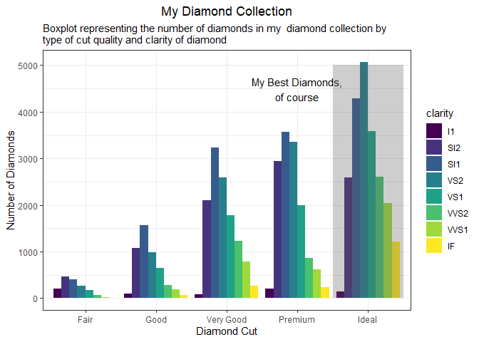

```r
ggplot(diamonds, aes(cut, fill = clarity)) +
  geom_bar(position = "dodge") +
  #To add labels to title, subtitle, x- and y-axes.
  labs(title = "My Diamond Collection",
       subtitle = "Boxplot representing the number of diamonds in my  diamond collection by \ntype of cut quality and clarity of diamond",
       x = "Diamond Cut",
       y = "Number of Diamonds") +
  theme(plot.title = element_text(hjust = 0.5)) +
  #annotate() to add the text and the rectangle
  annotate("text", x = 4, y = 4500,
           label = "My Best Diamonds,\nof course") +
  annotate("rect", xmin = 4.5, xmax = 5.5,
           ymin = 0, ymax = 5000,
           alpha = 0.3)
```

### Graph 2

```r
data("iris")
```

Using the iris dataset, make this graph:

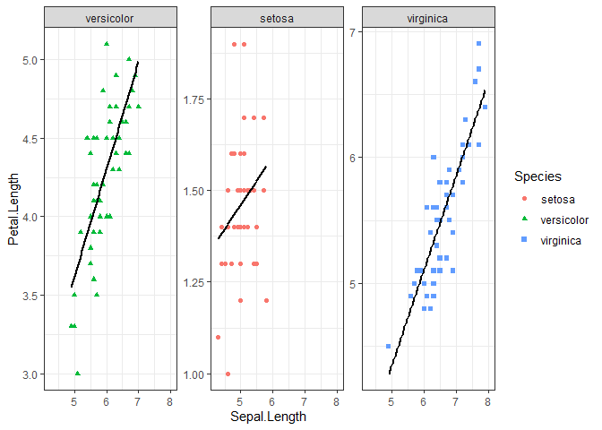

```r
#To reorder the panels within the graph
iris$Species2 <- factor(iris$Species, levels = c("versicolor", "setosa", "virginica"))

ggplot(iris, aes(Sepal.Length, Petal.Length, color = Species, shape = Species))+
  geom_point() +
  geom_smooth(se = F, method = lm, color = "black") +
  #To put species in different panels
  facet_wrap(vars(Species2), scales = "free") +
  #To resize x-axis per species
  scale_x_continuous(limits = c(4.25,8))
```